# Crystal Lake Metabolism (core figures)

### Limnology summary:

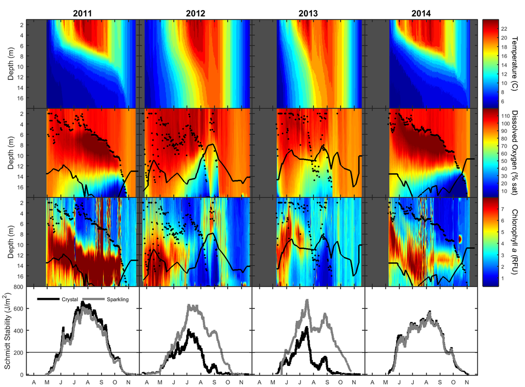

Figure 1. Crystal Lake (treatment) water temperature, dissolved oxygen percent saturation, and chlorophyll a. Black points and line delineate the upper mixed layer and photic depth respectively. Crystal and Sparkling (reference) lake Schmidt stability with 200 J/m^2 reference line marking periods of stratification.

### Metabolism summary:

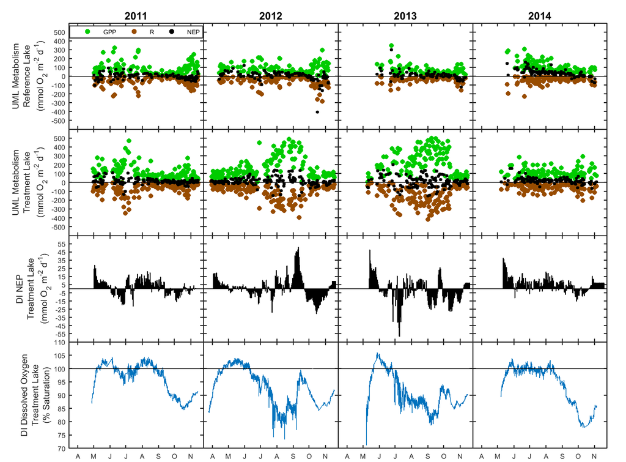

Figure 2. Sparkling Lake (reference) and Crystal Lake (treatment) upper mixed layer GPP, R, and NEP. Respiration rates are presented as negative values. Crystal Lake depth integrated NEP and dissolved oxygen percent saturation.

### Metabolism BACI:

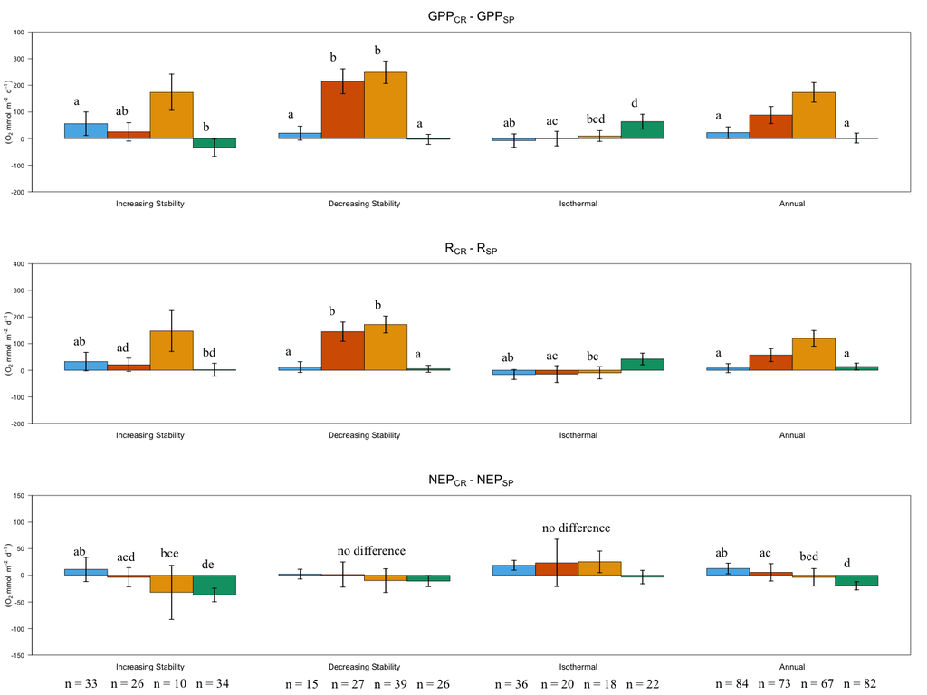

Figure 3a. Means and standard error of daily upper mixed layer metabolism (Crystal Lake - Sparkling Lake) grouped into four periods: Increasing stability, decreasing stability, isothermal, and annual. Blue = 2011, red = 2012, orange = 2013, green = 2014. Number of samples for each year and within each season are listed at the bottom of the figure. One-way ANOVA, on each season, revealed statistically significant differences. Tukey-Kramer post-hoc test revealed non-significant differences between years (within a season) noted by letters. Standard error has not been corrected for autocorrelation.

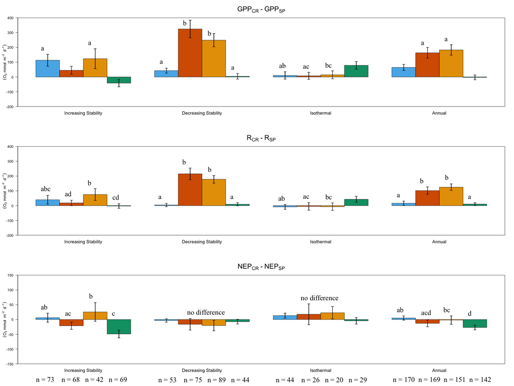

Figure 3b. Same as figure 3b, except all metabolism estimates were included. Data used in figure 3a only included days where R < 0 and GPP > 0.

### Depth Integrated NEP:

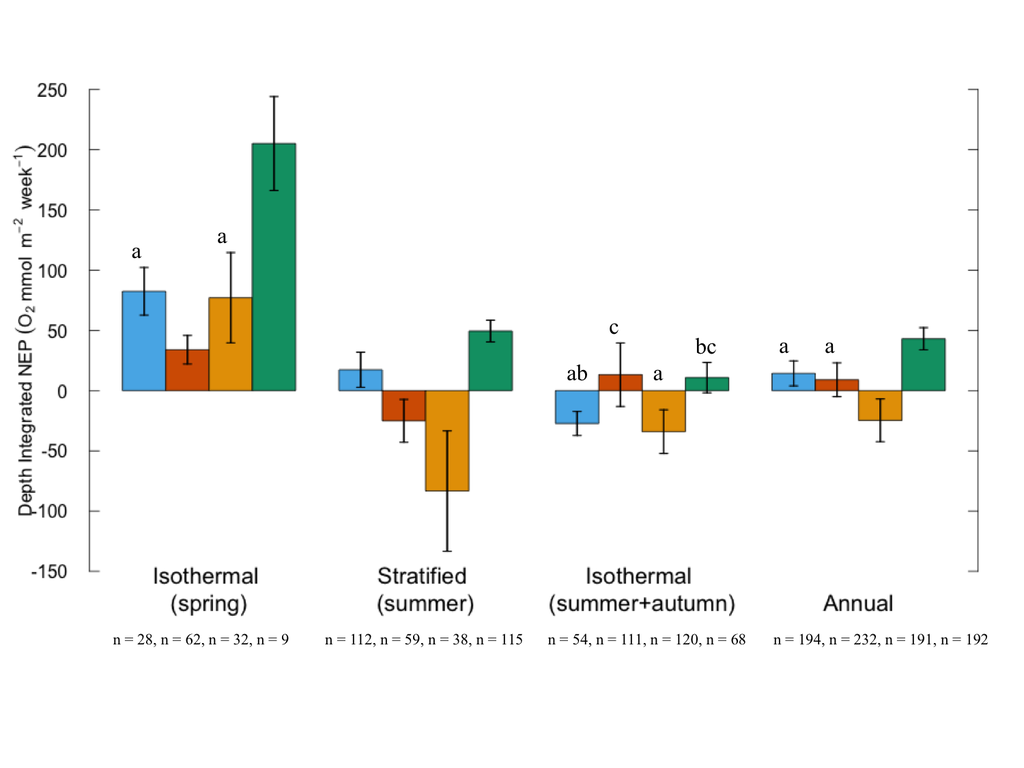

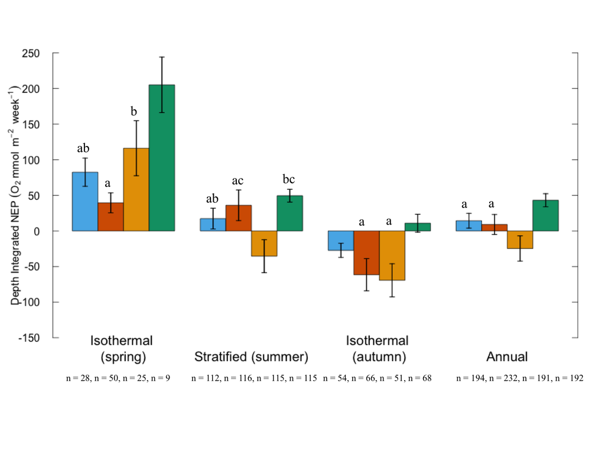

Figure 4b. Same as figure 4a except data are grouped to periods of Sparkling Lake stratification (Schmidt stability > 200 J/m^2).

### NEP (UML vs. DI):

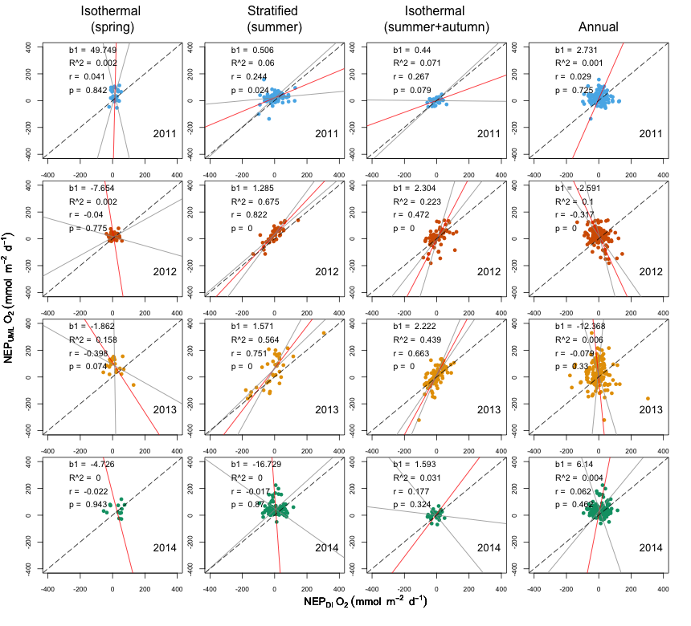

Figure 5a. Daily Crystal Lake upper mixed layer NEP vs. depth integrated NEP grouped to periods of Crystal Lake stratification (Schmidt stability > 200 J/m^2). Dashed line is 1:1. Solid red line is the type II major axis regression line bounded by confidence intervals. Regression slope, R^2, correlation coefficient, and p-value are presented.

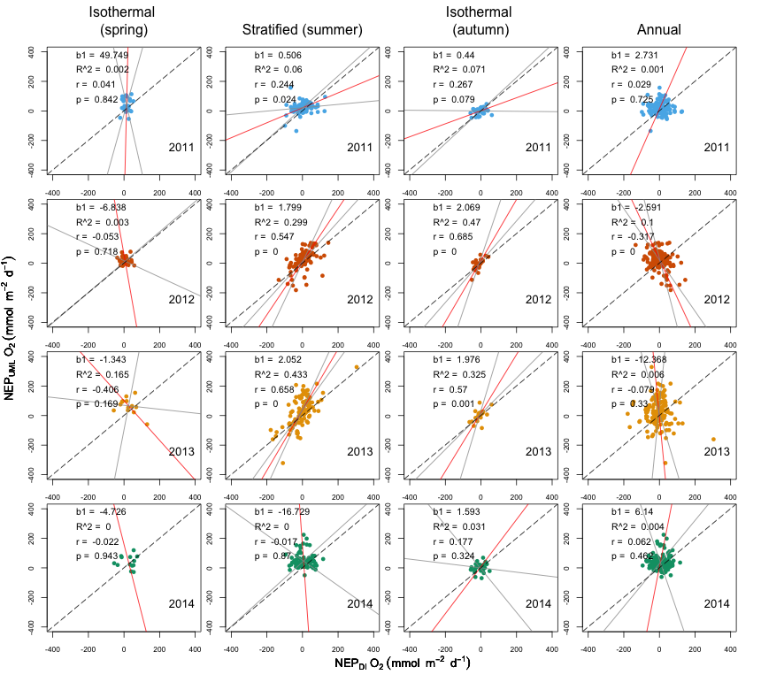

Figure 5b. Same as figure 5a except data are grouped to periods of Sparkling Lake stratification (Schmidt stability > 200 J/m^2).